# Immune cell exploratory data analysis

Scott Campit

# Summary

1. 7 days: Pre-metastatic niche - tumor cells have not arrived
2. 14 days: Metastatic niche - tumor cells arrived but no proliferation
3. 21 days: Metabstatic niche - secondary tumors in lung

**The overall hypothesis** is that immune cells at the early metastatic niche have an anti-tumor phenotype, while immune cells have a pro-metastatic niche in the late-stage.

I will be testing the following hypotheses that are reported across multiple studies using COBRA: * Glutathione metabolism will go down from the early stage to late stage metastatic niche. * Glycolysis will go up from the early stage to late stage metastatic niche. * OXPHOS goes down from early stage to late stage metastatic niche.

These are the known hypotheses that can support what already been known. Some additional questions I can attempt to answer include: * What are distinct metabolic flux alterations that occur in different immune cells?

# Exploratory data analysis

```r
unique(neutrophils@meta.data[["CellType"]])
```

[output not shown]

## Data Summary

First, let’s get the gene names

```r
lung_data = GetAssayData(lung, assay="RNA", slot='data')
gene_symbol = lung_data@Dimnames[[1]]
```

The code block below is for summarizing the dataset. Specifically, the for loop below counts the number of cells belonging to each cell type and time point.

```r
# Creating the count matrix
cnt_mat = matrix(, nrow=13, ncol=4)
for(i in 1:length(celltype.list)){
  cnt_mat[i, 1] = sum(celltype.list[[i]]@meta.data$Time == 0)
  cnt_mat[i, 2] = sum(celltype.list[[i]]@meta.data$Time == 7)
  cnt_mat[i, 3] = sum(celltype.list[[i]]@meta.data$Time == 14)
  cnt_mat[i, 4] = sum(celltype.list[[i]]@meta.data$Time == 21)
}
```

## Data visualization from dimension reduction

Now, let’s get a high level overview of the data using t-SNE and UMAP.

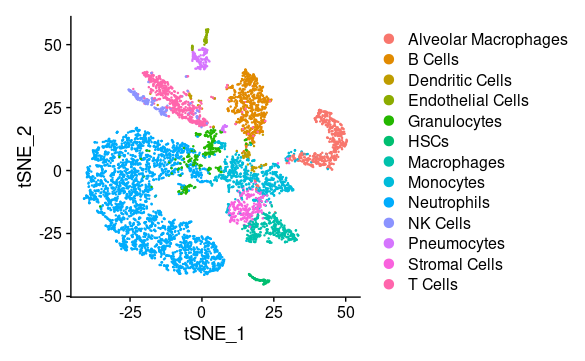

```r
# Sophia already ran tSNE
DimPlot(lung, reduction="tsne")
```

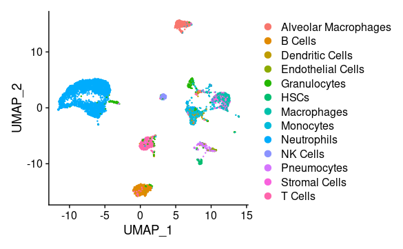

```r
# Let's also run UMAP to see if we get better separation
lung = RunUMAP(lung, dims=1:50)
DimPlot(lung, reduction='umap')
```

```r
# Separate by cell types
celltype.list = SplitObject(lung, split.by="CellType")
neutrophils = celltype.list$Neutrophils
```

```r
neutrophil_phate = phate(neutrophil_pca)
```

```
Error: $ operator is invalid for atomic vectors
```

[figure not shown]

```r
# Visualize T-SNE
neutrophils = RunTSNE(object=neutrophils)
DimPlot(neutrophils, reduction='tsne')
```